# ReneWind

Renewable energy sources play an increasingly important role in the global energy mix, as the effort to reduce the environmental impact of energy production increases.

Out of all the renewable energy alternatives, wind energy is one of the most developed technologies worldwide. The U.S Department of Energy has put together a guide to achieving operational efficiency using predictive maintenance practices.

Predictive maintenance uses sensor information and analysis methods to measure and predict degradation and future component capability. The idea behind predictive maintenance is that failure patterns are predictable and if component failure can be predicted accurately and the component is replaced before it fails, the costs of operation and maintenance will be much lower.

The sensors fitted across different machines involved in the process of energy generation collect data related to various environmental factors (temperature, humidity, wind speed, etc.) and additional features related to various parts of the wind turbine (gearbox, tower, blades, break, etc.).

## Objective

“ReneWind” is a company working on improving the machinery/processes involved in the production of wind energy using machine learning and has collected data of generator failure of wind turbines using sensors. They have shared a ciphered version of the data, as the data collected through sensors is confidential (the type of data collected varies with companies). Data has 40 predictors, 40000 observations in the training set and 10000 in the test set.

The objective is to build various classification models, tune them and find the best one that will help identify failures so that the generator could be repaired before failing/breaking and the overall maintenance cost of the generators can be brought down.

“1” in the target variables should be considered as “failure” and “0” will represent “No failure”.

The nature of predictions made by the classification model will translate as follows:

- True positives (TP) are failures correctly predicted by the model.
- False negatives (FN) are real failures in a wind turbine where there is no detection by model.
- False positives (FP) are detections in a wind turbine where there is no failure.

So, the maintenance cost associated with the model would be:

**Maintenance cost** = `TP*(Repair cost) + FN*(Replacement cost) + FP*(Inspection cost)` where,

- `Replacement cost = $40,000`
- `Repair cost = $15,000`
- `Inspection cost = $5,000`

Here the objective is to reduce the maintenance cost so, we want a metric that could reduce the maintenance cost.

- The minimum possible maintenance cost = `Actual failures*(Repair cost) = (TP + FN)*(Repair cost)`
- The maintenance cost associated with model = `TP*(Repair cost) + FN*(Replacement cost) + FP*(Inspection cost)`

So, we will try to maximize the ratio of minimum possible maintenance cost and the maintenance cost associated with the model.

The value of this ratio will lie between 0 and 1, the ratio will be 1 only when the maintenance cost associated with the model will be equal to the minimum possible maintenance cost.

## Data Description

- The data provided is a transformed version of original data which was collected using sensors.
- Train.csv - To be used for training and tuning of models.
- Test.csv - To be used only for testing the performance of the final best model.
- Both the datasets consist of 40 predictor variables and 1 target variable

## Importing libraries

```python
import pandas as pd

import matplotlib.pyplot as plt

import seaborn as sns

import numpy as np

from sklearn.impute import KNNImputer
from numpy import isnan

from sklearn.model_selection import train_test_split
from sklearn.metrics import f1_score
from sklearn.metrics import precision_score
from sklearn.metrics import recall_score
from sklearn.metrics import accuracy_score

from sklearn.metrics import plot_confusion_matrix
from sklearn.metrics import confusion_matrix


from sklearn.linear_model import LogisticRegression
from sklearn.tree import DecisionTreeClassifier
from sklearn.ensemble import RandomForestClassifier
from sklearn.ensemble import GradientBoostingClassifier
from sklearn.ensemble import AdaBoostClassifier
from imblearn.over_sampling import SMOTE
from imblearn.under_sampling import RandomUnderSampler
from sklearn.model_selection import GridSearchCV
from sklearn.pipeline import Pipeline
from sklearn.metrics import roc_auc_score
from sklearn.metrics import roc_curve
from matplotlib import pyplot
```

```python
%%javascript
IPython.OutputArea.prototype._should_scroll = function(lines) {
    return false;
}
```

```python
from IPython.display import HTML
HTML('''<script>
code_show_err=false;
function code_toggle_err() {
 if (code_show_err){
 $('div.output_stderr').hide();
 } else {
 $('div.output_stderr').show();
 }
 code_show_err = !code_show_err
}
$( document ).ready(code_toggle_err);
</script>
To toggle on/off output_stderr, click <a href="javascript:code_toggle_err()">here</a>.''')
```

To toggle on/off output_stderr, click here.

## Loading Data

```python
df = pd.read_csv("Train.csv")
```

```python
df.head(10)
```

|  | V1 | V2 | V3 | V4 | V5 | V6 | V7 | V8 | V9 | V10 | ... | V32 | V33 | V34 | V35 | V36 | V37 | V38 | V39 | V40 | Target |
| --- | --- | --- | --- | --- | --- | --- | --- | --- | --- | --- | --- | --- | --- | --- | --- | --- | --- | --- | --- | --- | --- |
| 0 | -4.464606 | -4.679129 | 3.101546 | 0.506130 | -0.221083 | -2.032511 | -2.910870 | 0.050714 | -1.522351 | 3.761892 | ... | 3.059700 | -1.690440 | 2.846296 | 2.235198 | 6.667486 | 0.443809 | -2.369169 | 2.950578 | -3.480324 | 0 |
| 1 | -2.909996 | -2.568662 | 4.109032 | 1.316672 | -1.620594 | -3.827212 | -1.616970 | 0.669006 | 0.387045 | 0.853814 | ... | -3.782686 | -6.823172 | 4.908562 | 0.481554 | 5.338051 | 2.381297 | -3.127756 | 3.527309 | -3.019581 | 0 |
| 2 | 4.283674 | 5.105381 | 6.092238 | 2.639922 | -1.041357 | 1.308419 | -1.876140 | -9.582412 | 3.469504 | 0.763395 | ... | -3.097934 | 2.690334 | -1.643048 | 7.566482 | -3.197647 | -3.495672 | 8.104779 | 0.562085 | -4.227426 | 0 |
| 3 | 3.365912 | 3.653381 | 0.909671 | -1.367528 | 0.332016 | 2.358938 | 0.732600 | -4.332135 | 0.565695 | -0.101080 | ... | -1.795474 | 3.032780 | -2.467514 | 1.894599 | -2.297780 | -1.731048 | 5.908837 | -0.386345 | 0.616242 | 0 |
| 4 | -3.831843 | -5.824444 | 0.634031 | -2.418815 | -1.773827 | 1.016824 | -2.098941 | -3.173204 | -2.081860 | 5.392621 | ... | -0.257101 | 0.803550 | 4.086219 | 2.292138 | 5.360850 | 0.351993 | 2.940021 | 3.839160 | -4.309402 | 0 |
| 5 | 1.618098 | 1.888342 | 7.046143 | -1.147285 | 0.083080 | -1.529780 | 0.207309 | -2.493629 | 0.344926 | 2.118578 | ... | -3.584425 | -2.577474 | 1.363769 | 0.622714 | 5.550100 | -1.526796 | 0.138853 | 3.101430 | -1.277378 | 0 |
| 6 | -0.111440 | 3.872488 | -3.758361 | -2.982897 | 3.792714 | 0.544960 | 0.205433 | 4.848994 | -1.854920 | -6.220023 | ... | 8.265896 | 6.629213 | -10.068689 | 1.222987 | -3.229763 | 1.686909 | -2.163896 | -3.644622 | 6.510338 | 0 |
| 7 | 0.159623 | -4.233781 | -0.264310 | -5.477119 | -0.190854 | -0.356274 | -0.134486 | 4.066608 | -3.858569 | 1.692441 | ... | 3.227235 | 0.628900 | -1.548860 | 1.321979 | 5.461345 | 1.109410 | -3.869993 | 0.273964 | 2.805941 | 0 |
| 8 | -3.644913 | -1.040955 | 2.425282 | 1.465421 | -0.421516 | -1.515841 | -0.955096 | 1.160726 | -2.023863 | 1.212668 | ... | 2.319396 | 2.079227 | 2.214099 | 3.287809 | 1.366954 | -0.303671 | -0.381396 | 1.090279 | -2.591694 | 0 |
| 9 | -0.184565 | -4.721470 | 0.864988 | -3.078695 | -2.226888 | -1.282220 | -0.804717 | 3.289733 | -1.567971 | 0.749904 | ... | -0.544941 | -0.762921 | 0.815558 | 1.889373 | 3.624347 | 1.555740 | -5.432884 | 0.678703 | 0.464697 | 0 |

10 rows × 41 columns

```python
df.dtypes
```

```
V1        float64
V2        float64
V3        float64
V4        float64
V5        float64
V6        float64
V7        float64
V8        float64
V9        float64
V10       float64
V11       float64
V12       float64
V13       float64
V14       float64
V15       float64
V16       float64
V17       float64
V18       float64
V19       float64
V20       float64
V21       float64
V22       float64
V23       float64
V24       float64
V25       float64
V26       float64
V27       float64
V28       float64
V29       float64
V30       float64
V31       float64
V32       float64
V33       float64
V34       float64
V35       float64
V36       float64
V37       float64
V38       float64
V39       float64
V40       float64
Target      int64
dtype: object
```

```python
df.describe().T
```

|  | count | mean | std | min | 25% | 50% | 75% | max |
| --- | --- | --- | --- | --- | --- | --- | --- | --- |
| V1 | 39954.0 | -0.288120 | 3.449072 | -13.501880 | -2.751460 | -0.773518 | 1.836708 | 17.436981 |
| V2 | 39961.0 | 0.442672 | 3.139431 | -13.212051 | -1.638355 | 0.463939 | 2.537508 | 13.089269 |
| V3 | 40000.0 | 2.505514 | 3.406263 | -11.469369 | 0.202682 | 2.265319 | 4.584920 | 18.366477 |
| V4 | 40000.0 | -0.066078 | 3.437330 | -16.015417 | -2.349574 | -0.123691 | 2.148596 | 13.279712 |
| V5 | 40000.0 | -0.044574 | 2.107183 | -8.612973 | -1.507206 | -0.096824 | 1.346224 | 9.403469 |
| V6 | 40000.0 | -1.000849 | 2.036756 | -10.227147 | -2.363446 | -1.006635 | 0.373909 | 7.065470 |
| V7 | 40000.0 | -0.892793 | 1.756510 | -8.205806 | -2.036913 | -0.934738 | 0.206820 | 8.006091 |
| V8 | 40000.0 | -0.563123 | 3.298916 | -15.657561 | -2.660415 | -0.384188 | 1.714383 | 11.679495 |
| V9 | 40000.0 | -0.007739 | 2.161833 | -8.596313 | -1.493676 | -0.052085 | 1.425713 | 8.507138 |
| V10 | 40000.0 | -0.001848 | 2.183034 | -11.000790 | -1.390549 | 0.105779 | 1.486105 | 8.108472 |
| V11 | 40000.0 | -1.917794 | 3.116426 | -14.832058 | -3.940969 | -1.941726 | 0.089444 | 13.851834 |
| V12 | 40000.0 | 1.578095 | 2.914613 | -13.619304 | -0.431373 | 1.485367 | 3.540787 | 15.753586 |
| V13 | 40000.0 | 1.591309 | 2.865222 | -13.830128 | -0.208522 | 1.653836 | 3.476336 | 15.419616 |
| V14 | 40000.0 | -0.946620 | 1.787759 | -8.309443 | -2.164513 | -0.957444 | 0.265874 | 6.213289 |
| V15 | 40000.0 | -2.435720 | 3.341244 | -17.201998 | -4.451365 | -2.398608 | -0.381757 | 12.874679 |
| V16 | 40000.0 | -2.943168 | 4.211646 | -21.918711 | -5.631812 | -2.718600 | -0.112947 | 13.583212 |
| V17 | 40000.0 | -0.142794 | 3.344332 | -17.633947 | -2.227048 | -0.027895 | 2.071801 | 17.404510 |
| V18 | 40000.0 | 1.188949 | 2.586164 | -11.643994 | -0.402848 | 0.867433 | 2.564239 | 13.179863 |
| V19 | 40000.0 | 1.181333 | 3.394979 | -13.491784 | -1.050903 | 1.278402 | 3.497277 | 16.059004 |
| V20 | 40000.0 | 0.027201 | 3.674985 | -13.922659 | -2.433811 | 0.030136 | 2.513245 | 16.052339 |
| V21 | 40000.0 | -3.621359 | 3.556979 | -19.436404 | -5.920847 | -3.559327 | -1.284178 | 13.840473 |
| V22 | 40000.0 | 0.943242 | 1.645538 | -10.122095 | -0.112147 | 0.962802 | 2.018031 | 7.409856 |
| V23 | 40000.0 | -0.387617 | 4.052147 | -16.187510 | -3.118868 | -0.275339 | 2.438047 | 15.080172 |
| V24 | 40000.0 | 1.142220 | 3.912820 | -18.487811 | -1.483210 | 0.963586 | 3.563055 | 19.769376 |
| V25 | 40000.0 | -0.003019 | 2.024691 | -8.228266 | -1.373400 | 0.021100 | 1.399816 | 8.223389 |
| V26 | 40000.0 | 1.895717 | 3.421454 | -12.587902 | -0.319231 | 1.963826 | 4.163146 | 16.836410 |
| V27 | 40000.0 | -0.616838 | 4.392161 | -14.904939 | -3.692075 | -0.909640 | 2.200608 | 21.594552 |
| V28 | 40000.0 | -0.888121 | 1.924947 | -9.685082 | -2.192763 | -0.904757 | 0.376856 | 6.906865 |
| V29 | 40000.0 | -1.005327 | 2.676299 | -12.579469 | -2.799008 | -1.206027 | 0.604473 | 11.852476 |
| V30 | 40000.0 | -0.032664 | 3.031009 | -14.796047 | -1.908202 | 0.184613 | 2.040131 | 13.190889 |
| V31 | 40000.0 | 0.505885 | 3.482735 | -19.376732 | -1.798975 | 0.491352 | 2.777519 | 17.255090 |
| V32 | 40000.0 | 0.326831 | 5.499369 | -23.200866 | -3.392115 | 0.056243 | 3.789241 | 24.847833 |
| V33 | 40000.0 | 0.056542 | 3.574219 | -17.454014 | -2.237550 | -0.049729 | 2.255985 | 16.692486 |
| V34 | 40000.0 | -0.464127 | 3.185712 | -17.985094 | -2.127757 | -0.250842 | 1.432885 | 14.358213 |
| V35 | 40000.0 | 2.234861 | 2.924185 | -15.349803 | 0.332081 | 2.110125 | 4.044659 | 16.804859 |
| V36 | 40000.0 | 1.530020 | 3.819754 | -17.478949 | -0.937119 | 1.571511 | 3.996721 | 19.329576 |
| V37 | 40000.0 | -0.000498 | 1.778273 | -7.639952 | -1.265717 | -0.132620 | 1.160828 | 7.803278 |
| V38 | 40000.0 | -0.351199 | 3.964186 | -17.375002 | -3.016805 | -0.318724 | 2.291342 | 15.964053 |
| V39 | 40000.0 | 0.900035 | 1.751022 | -7.135788 | -0.261578 | 0.921321 | 2.069016 | 7.997832 |
| V40 | 40000.0 | -0.897166 | 2.997750 | -11.930259 | -2.949590 | -0.949269 | 1.092178 | 10.654265 |
| Target | 40000.0 | 0.054675 | 0.227348 | 0.000000 | 0.000000 | 0.000000 | 0.000000 | 1.000000 |

```python
df.isnull().sum()
```

```
V1        46
V2        39
V3         0
V4         0
V5         0
V6         0
V7         0
V8         0
V9         0
V10        0
V11        0
V12        0
V13        0
V14        0
V15        0
V16        0
V17        0
V18        0
V19        0
V20        0
V21        0
V22        0
V23        0
V24        0
V25        0
V26        0
V27        0
V28        0
V29        0
V30        0
V31        0
V32        0
V33        0
V34        0
V35        0
V36        0
V37        0
V38        0
V39        0
V40        0
Target     0
dtype: int64
```

## Observation:

[output not shown]

## EDA and insights

```python
cols = [ 'V3', 'V4', 'V5', 'V6', 'V7', 'V8', 'V9', 'V10', 'V11',
       'V12', 'V13', 'V14', 'V15', 'V16', 'V17', 'V18', 'V19', 'V20', 'V21',
       'V22', 'V23', 'V24', 'V25', 'V26', 'V27', 'V28', 'V29', 'V30', 'V31',
       'V32', 'V33', 'V34', 'V35', 'V36', 'V37', 'V38', 'V39', 'V40']
```

[output not shown]

[output cut: 12 more lines]

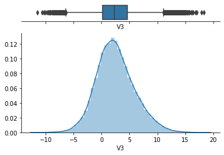

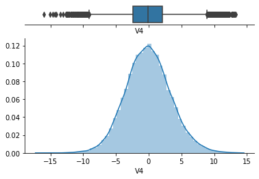

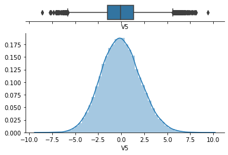

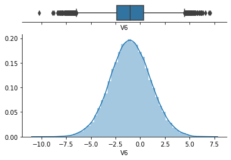

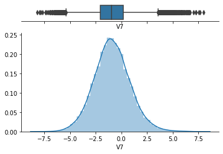

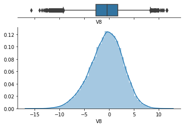

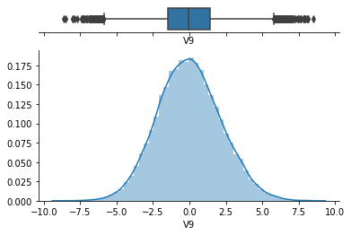

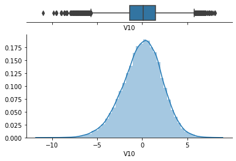

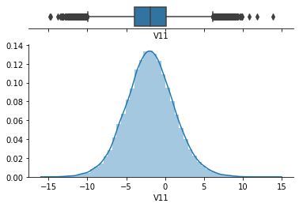

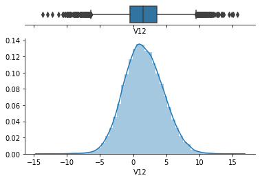

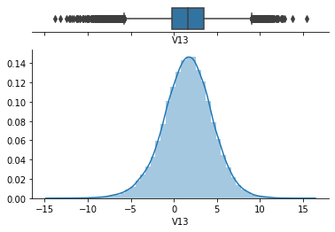

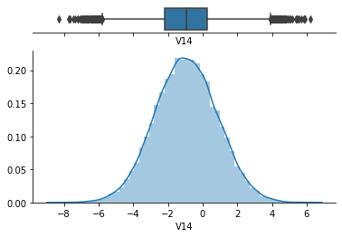

[26 more figures not shown]

```python
for col in cols:
    f, (ax_box, ax_hist) = plt.subplots(2, sharex=True,
                                    gridspec_kw={"height_ratios": (.15, .85)})

    sns.boxplot(df[col], ax=ax_box)
    sns.distplot(df[col], ax=ax_hist)

    ax_box.set(yticks=[])
    sns.despine(ax=ax_hist)
    sns.despine(ax=ax_box, left=True)
```

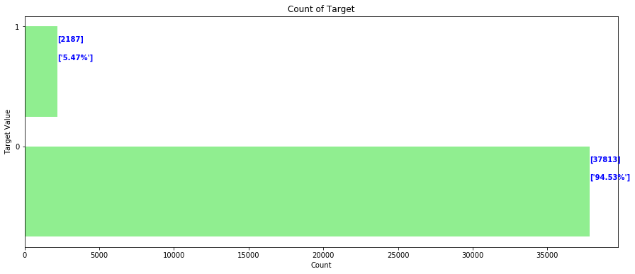

```python
fig, ax = plt.subplots(figsize=(15, 6))
width = 0.75 # the width of the bars
ind = np.arange(len(df.Target.value_counts() / len(df.Target)))  # the x locations for the groups
ax.barh(ind, df.Target.value_counts(), width, color="lightgreen")
ax.set_yticks(ind+width/2)
ax.set_yticklabels(df.Target.value_counts().keys(), minor=False)
plt.title('Count of Target')
plt.xlabel('Count')
plt.ylabel('Target Value')
for i, v in enumerate(df['Target'].value_counts().keys()):
    str1 = round((df[df.Target==v].Target.value_counts()/len(df.Target))*100,2).astype(str) +"%"
    x =df[df.Target==v].Target.value_counts()
    ax.text(x + 3, i + .1, str(str1.values), color='blue', fontweight='bold')
    ax.text(x + 3, i + .25, str(x.values), color='blue', fontweight='bold')
```

## Data Pre-processing

### Impute the V1 and V2 based on the KNN Imputer.

```python
X = df.iloc[: , :-1]
y=df[df.columns[-1]]
```

```python
imputer = KNNImputer()
imputer.fit(X)
X = imputer.transform(X)

print('Missing: %d' % sum(isnan(X).flatten()))
```

```
Missing: 0
```

```python
df_trans = pd.DataFrame(X, columns = df1.columns)
df_trans = df_trans.join(df[df.columns[-1]])
```

```python
df_trans.head()
```

|  | V1 | V2 | V3 | V4 | V5 | V6 | V7 | V8 | V9 | V10 | ... | V32 | V33 | V34 | V35 | V36 | V37 | V38 | V39 | V40 | Target |
| --- | --- | --- | --- | --- | --- | --- | --- | --- | --- | --- | --- | --- | --- | --- | --- | --- | --- | --- | --- | --- | --- |
| 0 | -4.464606 | -4.679129 | 3.101546 | 0.506130 | -0.221083 | -2.032511 | -2.910870 | 0.050714 | -1.522351 | 3.761892 | ... | 3.059700 | -1.690440 | 2.846296 | 2.235198 | 6.667486 | 0.443809 | -2.369169 | 2.950578 | -3.480324 | 0 |
| 1 | -2.909996 | -2.568662 | 4.109032 | 1.316672 | -1.620594 | -3.827212 | -1.616970 | 0.669006 | 0.387045 | 0.853814 | ... | -3.782686 | -6.823172 | 4.908562 | 0.481554 | 5.338051 | 2.381297 | -3.127756 | 3.527309 | -3.019581 | 0 |
| 2 | 4.283674 | 5.105381 | 6.092238 | 2.639922 | -1.041357 | 1.308419 | -1.876140 | -9.582412 | 3.469504 | 0.763395 | ... | -3.097934 | 2.690334 | -1.643048 | 7.566482 | -3.197647 | -3.495672 | 8.104779 | 0.562085 | -4.227426 | 0 |
| 3 | 3.365912 | 3.653381 | 0.909671 | -1.367528 | 0.332016 | 2.358938 | 0.732600 | -4.332135 | 0.565695 | -0.101080 | ... | -1.795474 | 3.032780 | -2.467514 | 1.894599 | -2.297780 | -1.731048 | 5.908837 | -0.386345 | 0.616242 | 0 |
| 4 | -3.831843 | -5.824444 | 0.634031 | -2.418815 | -1.773827 | 1.016824 | -2.098941 | -3.173204 | -2.081860 | 5.392621 | ... | -0.257101 | 0.803550 | 4.086219 | 2.292138 | 5.360850 | 0.351993 | 2.940021 | 3.839160 | -4.309402 | 0 |

5 rows × 41 columns

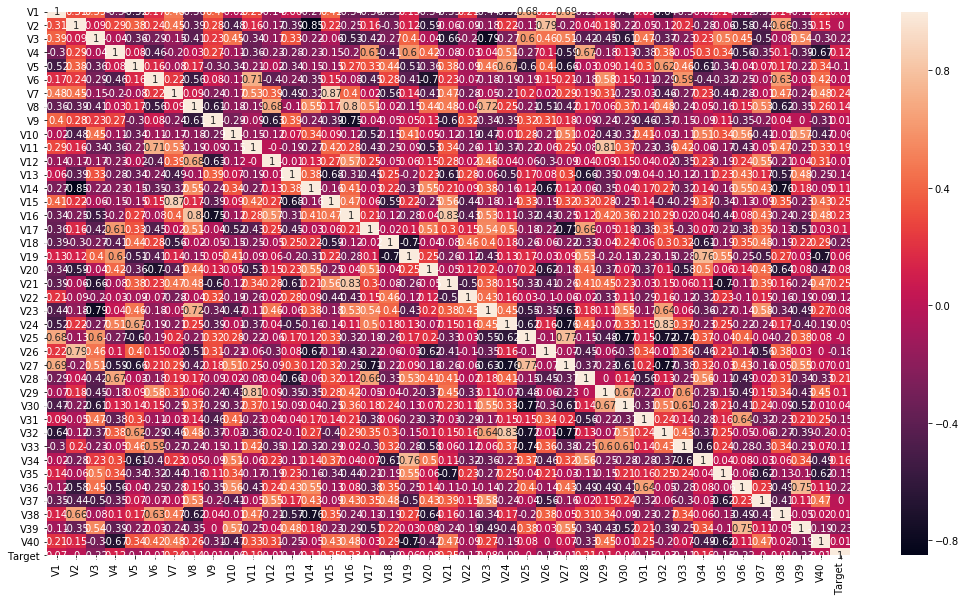

```python
corr = round(df_trans.corr(),2)
fig, ax = plt.subplots(figsize=(18, 10))
sns.heatmap(corr,annot=True)
```

## Model evaluation criterion

### 3 types of cost are associated with the provided problem

1. Replacement cost - False Negatives - Predicting no failure, while there will be a failure
2. Inspection cost - False Positives - Predicting failure, while there is no failure
3. Repair cost - True Positives - Predicting failure correctly

### How to reduce the overall cost?

- We need to create a customized metric, that can help to bring down the overall cost.
- The cost associated with any model = TP *15000 + FP* 5000 + FN * 40000
- And the minimum possible cost will be when, the model will be able to identify all failures, in that case, the cost will be (TP + FN) * 15000
- So, we will try to maximize `Minimum cost/Cost associated with model`

**Let's create two functions to calculate different metrics and confusion matrix, so that we don't have to use the same code repeatedly for each model.**

```python
# defining a function to compute different metrics to check performance of a classification model built using sklearn
def model_performance_classification_sklearn(model, predictors, target):
    """
    Function to compute different metrics to check classification model performance

    model: classifier
    predictors: independent variables
    target: dependent variable
    """

    TP = confusion_matrix(target, model.predict(predictors))[1, 1]
    FP = confusion_matrix(target, model.predict(predictors))[0, 1]
    FN = confusion_matrix(target, model.predict(predictors))[1, 0]
    Cost = TP * 15 + FP * 5 + FN * 40  # maintenance cost by using model
    Min_Cost = (TP + FN) * 15  # minimum possible maintenance cost = number of actual positives
    Percent = Min_Cost / Cost  # ratio of minimum possible maintenance cost and maintenance cost by model

    # predicting using the independent variables
    pred = model.predict(predictors)

    acc = accuracy_score(target, pred)  # to compute Accuracy
    recall = recall_score(target, pred)  # to compute Recall
    precision = precision_score(target, pred)  # to compute Precision
    f1 = f1_score(target, pred)  # to compute F1-score

    # creating a dataframe of metrics
    df_perf = pd.DataFrame(
        {
            "Accuracy": acc,
            "Recall": recall,
            "Precision": precision,
            "F1": f1,
            "Minimum_Vs_Model_cost": Percent,
        },
        index=[0],
    )

    return df_perf
```

```python
def confusion_matrix_sklearn(model, predictors, target):
    """
    To plot the confusion_matrix with percentages

    model: classifier
    predictors: independent variables
    target: dependent variable
    """
    y_pred = model.predict(predictors)
    cm = confusion_matrix(target, y_pred)
    labels = np.asarray(
        [
            ["{0:0.0f}".format(item) + "\n{0:.2%}".format(item / cm.flatten().sum())]
            for item in cm.flatten()
        ]
    ).reshape(2, 2)

    plt.figure(figsize=(6, 4))
    sns.heatmap(cm, annot=labels, fmt="")
    plt.ylabel("True label")
    plt.xlabel("Predicted label")
```

## **Defining scorer to be used for hyperparameter tuning**

- Every prediction of a classification model will be either a TP, FP, FN or TN.
- Till now at most of the places we wanted to reduce False negatives and hence we tried to maximize "Recall".
- To maximize Recall, we used Recall as a **scorer** in hyperparameter tuning.
- Here, we not only want to minimize false negatives but also false positives and we are also given the costs associated with each type of prediction.
- So, overall we want to reduce the maintenance cost which is: `TP*(Repair cost) + FN*(Replacement cost) + FP*(Inspection cost)`
- In simple language, we can say that we are assigning different weightage to the different types of predictions.
- Do we have any such metric which can help us minimize the maintenance cost? i.e., help us reduce FP and FN as per the weightage - We don't have any such inbuilt metric.
- In sklearn, we can define **custom scorers** also as per our need.
- For this classification problem, we need to reduce the maintenance cost, which can be reiterated as:
  - Minimize (maintenance cost)
  - Maximize (1/maintenance cost)
  - Maximize (minimum possible maintenance cost/maintenance cost)
- Eventually, all 3 metrics will do the same work in the backend and the only difference will be in the scale of the values of the metric.
- The metric provided in the next cell is to `maximize(minimum possible maintenance cost/maintenance cost)`
- You can modify the metric as per convenience and use it further to tune the models.

```python
from sklearn import metrics
```

```python
# defining metric to be used for optimization and with cross-validation
def Minimum_Vs_Model_cost(y_train, y_pred):
    """
    We want the model to optimize the maintenance cost and reduce it to the lowest possible value.
    The lowest possible maintenance cost will be achieved when each sample is predicted correctly.

    In such a scenario, the maintenance cost will be the total number of failures times the maintenance cost of replacing one generator,
    which is given by (TP + FN) * 40 (i.e., the actual positives*40).
    For any other scenario,
    the maintenance cost associated with the model will be given by (TP * 15 + FP * 5 + FN * 40).

    We will use the ratio of these two maintenance costs as the cost function for our model.
    The greater the ratio, the lower the associated maintenance cost and the better the model.
    """
    TP = confusion_matrix(y_train, y_pred)[1, 1]
    FP = confusion_matrix(y_train, y_pred)[0, 1]
    FN = confusion_matrix(y_train, y_pred)[1, 0]
    return ((TP + FN) * 15) / (TP * 15 + FP * 5 + FN * 40)


# A value of .80 here, will represent that the minimum maintenance cost is 80% of the maintenance cost associated with the model.
# Since minimum maintenance cost is constant for any data, when minimum cost will become 100% of maintenance cost associated with the model
# Model will have give the least possible maintenance cost.


# Type of scoring used to compare parameter combinations
scorer = metrics.make_scorer(Minimum_Vs_Model_cost, greater_is_better=True)

# Higher the values, the lower the maintenance cost
```

## Model Building with Original data

```python
X_train, X_test, y_train, y_test = train_test_split(X, y, test_size=0.3, random_state=1, stratify=y)
```

### Model #1 : Logistic Regression

```python
LG =  LogisticRegression()
LG.fit(X_train, y_train)
y_pred = LG.predict(X_test)

model_performance_classification_sklearn(LG,X_test,y_test)
```

[output not shown]

```python
model_performance_classification_sklearn(LG,X_train,y_train)
```

|  | Accuracy | Recall | Precision | F1 | Minimum_Vs_Model_cost |
| --- | --- | --- | --- | --- | --- |
| 0 | 0.967643 | 0.48857 | 0.858783 | 0.622814 | 0.532152 |

### Model 2 : Decision Tree

```python
clf = DecisionTreeClassifier()
clf.fit(X_train, y_train)
y_pred = clf.predict(X_test)

model_performance_classification_sklearn(clf,X_test,y_test)
```

|  | Accuracy | Recall | Precision | F1 | Minimum_Vs_Model_cost |
| --- | --- | --- | --- | --- | --- |
| 0 | 0.9695 | 0.746951 | 0.710145 | 0.728083 | 0.656438 |

```python
model_performance_classification_sklearn(clf,X_train,y_train)
```

|  | Accuracy | Recall | Precision | F1 | Minimum_Vs_Model_cost |
| --- | --- | --- | --- | --- | --- |
| 0 | 1.0 | 1.0 | 1.0 | 1.0 | 1.0 |

### Model #3 : Random Forest

```python
forest = RandomForestClassifier()
forest.fit(X_train, y_train)
y_pred = forest.predict(X_test)

model_performance_classification_sklearn(forest,X_test,y_test)
```

|  | Accuracy | Recall | Precision | F1 | Minimum_Vs_Model_cost |
| --- | --- | --- | --- | --- | --- |
| 0 | 0.986417 | 0.760671 | 0.988119 | 0.859604 | 0.713302 |

```python
model_performance_classification_sklearn(forest,X_train,y_train)
```

|  | Accuracy | Recall | Precision | F1 | Minimum_Vs_Model_cost |
| --- | --- | --- | --- | --- | --- |
| 0 | 1.0 | 1.0 | 1.0 | 1.0 | 1.0 |

### Model #4 : Ada Boost

```python
AB = AdaBoostClassifier()
AB.fit(X_train, y_train)
y_pred = AB.predict(X_test)

model_performance_classification_sklearn(AB,X_test,y_test)
```

|  | Accuracy | Recall | Precision | F1 | Minimum_Vs_Model_cost |
| --- | --- | --- | --- | --- | --- |
| 0 | 0.971667 | 0.605183 | 0.830544 | 0.700176 | 0.588517 |

```python
model_performance_classification_sklearn(AB,X_train,y_train)
```

|  | Accuracy | Recall | Precision | F1 | Minimum_Vs_Model_cost |
| --- | --- | --- | --- | --- | --- |
| 0 | 0.975714 | 0.627041 | 0.898036 | 0.738462 | 0.607781 |

### Model #5 : Gradient Boost

```python
GB = GradientBoostingClassifier()
GB.fit(X_train, y_train)
y_pred = GB.predict(X_test)

model_performance_classification_sklearn(GB,X_test,y_test)
```

|  | Accuracy | Recall | Precision | F1 | Minimum_Vs_Model_cost |
| --- | --- | --- | --- | --- | --- |
| 0 | 0.981417 | 0.713415 | 0.930417 | 0.807593 | 0.668705 |

```python
model_performance_classification_sklearn(GB,X_train,y_train)
```

|  | Accuracy | Recall | Precision | F1 | Minimum_Vs_Model_cost |
| --- | --- | --- | --- | --- | --- |
| 0 | 0.987179 | 0.779229 | 0.982702 | 0.869217 | 0.728585 |

## Model Building with Oversampled data

```python
# Synthetic Minority Over Sampling Technique
sm = SMOTE(sampling_strategy=1, k_neighbors=5, random_state=1)
X_train_over, y_train_over = sm.fit_resample(X_train, y_train)
```

```python
y_train_over.value_counts()
```

```
1    26469
0    26469
Name: Target, dtype: int64
```

```python
y_train.value_counts()
```

```
0    26469
1     1531
Name: Target, dtype: int64
```

### Model 6 : Logistic Regression with Over Sampling(SMOTE)

```python
LG_SMOTE =  LogisticRegression()
LG_SMOTE.fit(X_train_over, y_train_over)
y_pred = LG_SMOTE.predict(X_test)

model_performance_classification_sklearn(LG_SMOTE,X_test,y_test)
```

|  | Accuracy | Recall | Precision | F1 | Minimum_Vs_Model_cost |
| --- | --- | --- | --- | --- | --- |
| 0 | 0.872667 | 0.841463 | 0.279352 | 0.419453 | 0.503067 |

```python
model_performance_classification_sklearn(LG_SMOTE,X_train_over,y_train_over)
```

|  | Accuracy | Recall | Precision | F1 | Minimum_Vs_Model_cost |
| --- | --- | --- | --- | --- | --- |
| 0 | 0.873947 | 0.875175 | 0.873031 | 0.874101 | 0.7997 |

### Model 7 : Decision Tree with Over Sampling (SMOTE)

```python
clf_SMOTE = DecisionTreeClassifier()
clf_SMOTE.fit(X_train_over, y_train_over)
y_pred = clf_SMOTE.predict(X_test)

model_performance_classification_sklearn(clf_SMOTE,X_test,y_test)
```

|  | Accuracy | Recall | Precision | F1 | Minimum_Vs_Model_cost |
| --- | --- | --- | --- | --- | --- |
| 0 | 0.947 | 0.818598 | 0.509488 | 0.62807 | 0.638961 |

```python
model_performance_classification_sklearn(clf_SMOTE,X_train_over,y_train_over)
```

|  | Accuracy | Recall | Precision | F1 | Minimum_Vs_Model_cost |
| --- | --- | --- | --- | --- | --- |
| 0 | 1.0 | 1.0 | 1.0 | 1.0 | 1.0 |

### Model 8 : Random Forest with Over Sampling(SMOTE)

```python
forest_SMOTE = RandomForestClassifier()
forest_SMOTE.fit(X_train_over, y_train_over)
y_pred = forest_SMOTE.predict(X_test)

model_performance_classification_sklearn(forest_SMOTE,X_test,y_test)
```

|  | Accuracy | Recall | Precision | F1 | Minimum_Vs_Model_cost |
| --- | --- | --- | --- | --- | --- |
| 0 | 0.990167 | 0.86128 | 0.954392 | 0.905449 | 0.803265 |

```python
model_performance_classification_sklearn(forest_SMOTE,X_train_over,y_train_over)
```

|  | Accuracy | Recall | Precision | F1 | Minimum_Vs_Model_cost |
| --- | --- | --- | --- | --- | --- |
| 0 | 1.0 | 1.0 | 1.0 | 1.0 | 1.0 |

```python
AB_SMOTE = AdaBoostClassifier()
AB_SMOTE.fit(X_train, y_train)
y_pred = AB_SMOTE.predict(X_test)

model_performance_classification_sklearn(AB_SMOTE,X_test,y_test)
```

|  | Accuracy | Recall | Precision | F1 | Minimum_Vs_Model_cost |
| --- | --- | --- | --- | --- | --- |
| 0 | 0.971667 | 0.605183 | 0.830544 | 0.700176 | 0.588517 |

```python
model_performance_classification_sklearn(AB_SMOTE,X_train_over,y_train_over)
```

|  | Accuracy | Recall | Precision | F1 | Minimum_Vs_Model_cost |
| --- | --- | --- | --- | --- | --- |
| 0 | 0.806661 | 0.617439 | 0.993375 | 0.761539 | 0.610138 |

```python
GB_SMOTE = GradientBoostingClassifier()
GB_SMOTE.fit(X_train, y_train)
y_pred = GB_SMOTE.predict(X_test)

model_performance_classification_sklearn(GB_SMOTE,X_test,y_test)
```

|  | Accuracy | Recall | Precision | F1 | Minimum_Vs_Model_cost |
| --- | --- | --- | --- | --- | --- |
| 0 | 0.981333 | 0.71189 | 0.930279 | 0.806563 | 0.667571 |

```python
model_performance_classification_sklearn(GB_SMOTE,X_train_over,y_train_over)
```

|  | Accuracy | Recall | Precision | F1 | Minimum_Vs_Model_cost |
| --- | --- | --- | --- | --- | --- |
| 0 | 0.878443 | 0.757679 | 0.998954 | 0.861747 | 0.712183 |

## Model Building with Undersampled data

```python
# Random undersampler for under sampling the data
rus = RandomUnderSampler(random_state=1, sampling_strategy=1)
X_train_un, y_train_un = rus.fit_resample(X_train, y_train)
```

```python
y_train_un.value_counts()
```

```
1    1531
0    1531
Name: Target, dtype: int64
```

```python
y_train.value_counts()
```

```
0    26469
1     1531
Name: Target, dtype: int64
```

### Model #11 : Logistic Regression with Under Sampling

```python
LG_un =  LogisticRegression()
LG_un.fit(X_train_un, y_train_un)
y_pred = LG_SMOTE.predict(X_test)

model_performance_classification_sklearn(LG_un,X_test,y_test)
```

|  | Accuracy | Recall | Precision | F1 | Minimum_Vs_Model_cost |
| --- | --- | --- | --- | --- | --- |
| 0 | 0.867167 | 0.83689 | 0.269646 | 0.407875 | 0.493233 |

```python
model_performance_classification_sklearn(LG_un,X_train_un,y_train_un)
```

|  | Accuracy | Recall | Precision | F1 | Minimum_Vs_Model_cost |
| --- | --- | --- | --- | --- | --- |
| 0 | 0.854017 | 0.851731 | 0.855643 | 0.853682 | 0.772192 |

### Model #12 : Decision Tree with Under Sampling

```python
clf_un = DecisionTreeClassifier()
clf_un.fit(X_train_un, y_train_un)
y_pred = clf_un.predict(X_test)

model_performance_classification_sklearn(clf_un,X_test,y_test)
```

|  | Accuracy | Recall | Precision | F1 | Minimum_Vs_Model_cost |
| --- | --- | --- | --- | --- | --- |
| 0 | 0.85275 | 0.838415 | 0.248756 | 0.383676 | 0.473191 |

```python
model_performance_classification_sklearn(clf_un,X_train_un,y_train_un)
```

|  | Accuracy | Recall | Precision | F1 | Minimum_Vs_Model_cost |
| --- | --- | --- | --- | --- | --- |
| 0 | 1.0 | 1.0 | 1.0 | 1.0 | 1.0 |

### Model 13 Random Forest with Under Sampling

```python
forest_un = RandomForestClassifier()
forest_un.fit(X_train_un, y_train_un)
y_pred = forest_un.predict(X_test)

model_performance_classification_sklearn(forest_un,X_test,y_test)
```

|  | Accuracy | Recall | Precision | F1 | Minimum_Vs_Model_cost |
| --- | --- | --- | --- | --- | --- |
| 0 | 0.96525 | 0.88872 | 0.62891 | 0.736576 | 0.735151 |

```python
model_performance_classification_sklearn(forest_un,X_train_un,y_train_un)
```

|  | Accuracy | Recall | Precision | F1 | Minimum_Vs_Model_cost |
| --- | --- | --- | --- | --- | --- |
| 0 | 1.0 | 1.0 | 1.0 | 1.0 | 1.0 |

### Model #14 : Ada Boost with Under Sampling

```python
AB_un = AdaBoostClassifier()
AB_un.fit(X_train_un, y_train_un)
y_pred = AB_un.predict(X_test)

model_performance_classification_sklearn(AB_un,X_test,y_test)
```

|  | Accuracy | Recall | Precision | F1 | Minimum_Vs_Model_cost |
| --- | --- | --- | --- | --- | --- |
| 0 | 0.8965 | 0.862805 | 0.329453 | 0.476832 | 0.551261 |

```python
model_performance_classification_sklearn(AB_un,X_train_un,y_train_un)
```

|  | Accuracy | Recall | Precision | F1 | Minimum_Vs_Model_cost |
| --- | --- | --- | --- | --- | --- |
| 0 | 0.906597 | 0.881777 | 0.927835 | 0.90422 | 0.819739 |

### Model #15 : Gradient Boost with Under Sampling

```python
GB_un = GradientBoostingClassifier()
GB_un.fit(X_train_un, y_train_un)
y_pred = GB_un.predict(X_test)

model_performance_classification_sklearn(GB_un,X_test,y_test)
```

|  | Accuracy | Recall | Precision | F1 | Minimum_Vs_Model_cost |
| --- | --- | --- | --- | --- | --- |
| 0 | 0.949167 | 0.879573 | 0.520758 | 0.654195 | 0.680028 |

```python
model_performance_classification_sklearn(GB_un,X_train_un,y_train_un)
```

|  | Accuracy | Recall | Precision | F1 | Minimum_Vs_Model_cost |
| --- | --- | --- | --- | --- | --- |
| 0 | 0.947747 | 0.914435 | 0.979706 | 0.945946 | 0.870381 |

## Model Selection

```python
df_model_selection= pd.DataFrame()
```

```python
def model_selection_dataframe(SNO,Name,model, predictors, target):
    df_result = pd.DataFrame()
    df_model1=pd.DataFrame(columns=['SNO','Model Name'])
    df_model1 = df_model1.append({'SNO': SNO, 'Model Name': Name}, ignore_index = True)
    df_model2 = model_performance_classification_sklearn(model,predictors,target)
    df_result= pd.concat([df_model1,df_model2], axis=1, join="inner")
    return df_result
```

```python
model_selection_dataframe('1','Logistic Regression',LG,X_test,y_test)
```

|  | SNO | Model Name | Accuracy | Recall | Precision | F1 | Minimum_Vs_Model_cost |
| --- | --- | --- | --- | --- | --- | --- | --- |
| 0 | 1 | Logistic Regression | 0.96525 | 0.463415 | 0.823848 | 0.593171 | 0.518851 |

```python
df_model_selection = df_model_selection.append(model_selection_dataframe
                                               ('1','Logistic Regression',LG,X_test,y_test), ignore_index = True)
df_model_selection = df_model_selection.append(model_selection_dataframe
                                               ('2','Decision Tree',clf,X_test,y_test), ignore_index = True)
df_model_selection = df_model_selection.append(model_selection_dataframe
                                               ('3','Random Forest',forest,X_test,y_test), ignore_index = True)
df_model_selection = df_model_selection.append(model_selection_dataframe
                                               ('4','Ada Boost',AB,X_test,y_test), ignore_index = True)
df_model_selection = df_model_selection.append(model_selection_dataframe
                                               ('5','Gradient Boost',GB,X_test,y_test), ignore_index = True)

df_model_selection = df_model_selection.append(model_selection_dataframe
                                               ('6','Logistic Regression with Over Sampling',LG_SMOTE,X_test,y_test), ignore_index = True)
df_model_selection = df_model_selection.append(model_selection_dataframe
                                               ('7','Decision Tree with Over Sampling',clf_SMOTE,X_test,y_test), ignore_index = True)
df_model_selection = df_model_selection.append(model_selection_dataframe
                                               ('8','Random Forest with Over Sampling',forest_SMOTE,X_test,y_test), ignore_index = True)
df_model_selection = df_model_selection.append(model_selection_dataframe
                                               ('9','Ada Boost with Over Sampling',AB_SMOTE,X_test,y_test), ignore_index = True)
df_model_selection = df_model_selection.append(model_selection_dataframe
                                               ('10','Gradient Boost with Over Sampling',GB_SMOTE,X_test,y_test), ignore_index = True)


df_model_selection = df_model_selection.append(model_selection_dataframe
                                               ('11','Logistic Regression with Under Sampling',LG_un,X_test,y_test), ignore_index = True)
df_model_selection = df_model_selection.append(model_selection_dataframe
                                               ('12','Decision Tree with Under Sampling',clf_un,X_test,y_test), ignore_index = True)
df_model_selection = df_model_selection.append(model_selection_dataframe
                                               ('13','Random Forest with Under Sampling',forest_un,X_test,y_test), ignore_index = True)
df_model_selection = df_model_selection.append(model_selection_dataframe
                                               ('14','Ada Boost with Under Sampling',AB_un,X_test,y_test), ignore_index = True)
df_model_selection = df_model_selection.append(model_selection_dataframe
                                               ('15','Gradient Boost with Under Sampling',GB_un,X_test,y_test), ignore_index = True)
```

```python
df_model_selection
```

|  | SNO | Model Name | Accuracy | Recall | Precision | F1 | Minimum_Vs_Model_cost |
| --- | --- | --- | --- | --- | --- | --- | --- |
| 0 | 1 | Logistic Regression | 0.965250 | 0.463415 | 0.823848 | 0.593171 | 0.518851 |
| 1 | 2 | Decision Tree | 0.969500 | 0.746951 | 0.710145 | 0.728083 | 0.656438 |
| 2 | 3 | Random Forest | 0.986417 | 0.760671 | 0.988119 | 0.859604 | 0.713302 |
| 3 | 4 | Ada Boost | 0.971667 | 0.605183 | 0.830544 | 0.700176 | 0.588517 |
| 4 | 5 | Gradient Boost | 0.981417 | 0.713415 | 0.930417 | 0.807593 | 0.668705 |
| 5 | 6 | Logistic Regression with Over Sampling | 0.872667 | 0.841463 | 0.279352 | 0.419453 | 0.503067 |
| 6 | 7 | Decision Tree with Over Sampling | 0.947000 | 0.818598 | 0.509488 | 0.628070 | 0.638961 |
| 7 | 8 | Random Forest with Over Sampling | 0.990167 | 0.861280 | 0.954392 | 0.905449 | 0.803265 |
| 8 | 9 | Ada Boost with Over Sampling | 0.971667 | 0.605183 | 0.830544 | 0.700176 | 0.588517 |
| 9 | 10 | Gradient Boost with Over Sampling | 0.981333 | 0.711890 | 0.930279 | 0.806563 | 0.667571 |
| 10 | 11 | Logistic Regression with Under Sampling | 0.867167 | 0.836890 | 0.269646 | 0.407875 | 0.493233 |
| 11 | 12 | Decision Tree with Under Sampling | 0.852750 | 0.838415 | 0.248756 | 0.383676 | 0.473191 |
| 12 | 13 | Random Forest with Under Sampling | 0.965250 | 0.888720 | 0.628910 | 0.736576 | 0.735151 |
| 13 | 14 | Ada Boost with Under Sampling | 0.896500 | 0.862805 | 0.329453 | 0.476832 | 0.551261 |
| 14 | 15 | Gradient Boost with Under Sampling | 0.949167 | 0.879573 | 0.520758 | 0.654195 | 0.680028 |

## Observation

The Random Forest with Over Sampling ( Model 8) has Good F1 Score and effectively reducing the Maintance cost of Wind Energry Components . We can fine tune the Random Forest Further to improve the F1 Score and effectively reducing the maintance cost

## HyperparameterTuning

- **Hyperparameter tuning can take a long time to run, so to avoid that time complexity - you can use the following grids, wherever required.**

#### For XGBoost:

param_grid={'n_estimators':np.arange(150,300,50),'scale_pos_weight':[5,10], 'learning_rate':[0.1,0.2], 'gamma':[0,3,5], 'subsample':[0.8,0.9]}

#### For Gradient Boosting:

param_grid = { "init": [AdaBoostClassifier(random_state=1),DecisionTreeClassifier(random_state=1)], "n_estimators": np.arange(75,150,25), "learning_rate": [0.2, 0.05, 1], "subsample":[0.5,0.7], "max_features":[0.5,0.7]}

#### For Adaboost:

param_grid = { "n_estimators": np.arange(10, 110, 20), "learning_rate": [ 0.2, 0.05, 1], "base_estimator": [ DecisionTreeClassifier(max_depth=1, random_state=1), DecisionTreeClassifier(max_depth=2, random_state=1), DecisionTreeClassifier(max_depth=3, random_state=1)]}

#### For logistic Regression:

param_grid = {'C': np.arange(0.1,1.1,0.1)}

#### For Bagging Classifier:

param_grid = { 'max_samples': [0.8,0.9], 'max_features': [0.8,0.9], 'n_estimators' : [40,50]}

#### For Random Forest:

param_grid = { "n_estimators": [150,250], "min_samples_leaf": np.arange(1, 3), "max_features": ['sqrt','log2'], "max_samples": np.arange(0.2, 0.6, 0.1)}

#### For Decision Trees:

param_grid = {'max_depth': np.arange(2,20), 'min_samples_leaf': [1, 2, 5, 7], 'max_leaf_nodes' : [5, 10,15], 'min_impurity_decrease': [0.0001,0.001] }

```python
## Random Forest
param_grid = { "n_estimators": [150,250], "min_samples_leaf": np.arange(1, 3),
              "max_features": ['sqrt','log2'], "max_samples": np.arange(0.2, 0.6, 0.1)}
```

```python
Forest_Grid=RandomForestClassifier()
```

```python
Forest_Grid = GridSearchCV(estimator=Forest_Grid, param_grid=param_grid)
Forest_Grid.fit(X_train_over, y_train_over)
```

```
GridSearchCV(cv=None, error_score=nan,
             estimator=RandomForestClassifier(bootstrap=True, ccp_alpha=0.0,
                                              class_weight=None,
                                              criterion='gini', max_depth=None,
                                              max_features='auto',
                                              max_leaf_nodes=None,
                                              max_samples=None,
                                              min_impurity_decrease=0.0,
                                              min_impurity_split=None,
                                              min_samples_leaf=1,
                                              min_samples_split=2,
                                              min_weight_fraction_leaf=0.0,
                                              n_estimators=100, n_jobs=None,
                                              oob_score=False,
                                              random_state=None, verbose=0,
                                              warm_start=False),
             iid='deprecated', n_jobs=None,
             param_grid={'max_features': ['sqrt', 'log2'],
                         'max_samples': array([0.2, 0.3, 0.4, 0.5]),
                         'min_samples_leaf': array([1, 2]),
                         'n_estimators': [150, 250]},
             pre_dispatch='2*n_jobs', refit=True, return_train_score=False,
             scoring=None, verbose=0)
```

```python
forest_grid_param = RandomForestClassifier(criterion='gini',
                                              min_samples_leaf=1,
                                              min_samples_split=2,
                                              n_estimators=100)
forest_grid_param.fit(X_train_over, y_train_over)
y_pred = forest_grid_param.predict(X_test)

model_performance_classification_sklearn(forest_grid_param,X_test,y_test)
```

|  | Accuracy | Recall | Precision | F1 | Minimum_Vs_Model_cost |
| --- | --- | --- | --- | --- | --- |
| 0 | 0.990667 | 0.865854 | 0.959459 | 0.910256 | 0.809211 |

```python
model_performance_classification_sklearn(forest_grid_param,X_train_over,y_train_over)
```

|  | Accuracy | Recall | Precision | F1 | Minimum_Vs_Model_cost |
| --- | --- | --- | --- | --- | --- |
| 0 | 1.0 | 1.0 | 1.0 | 1.0 | 1.0 |

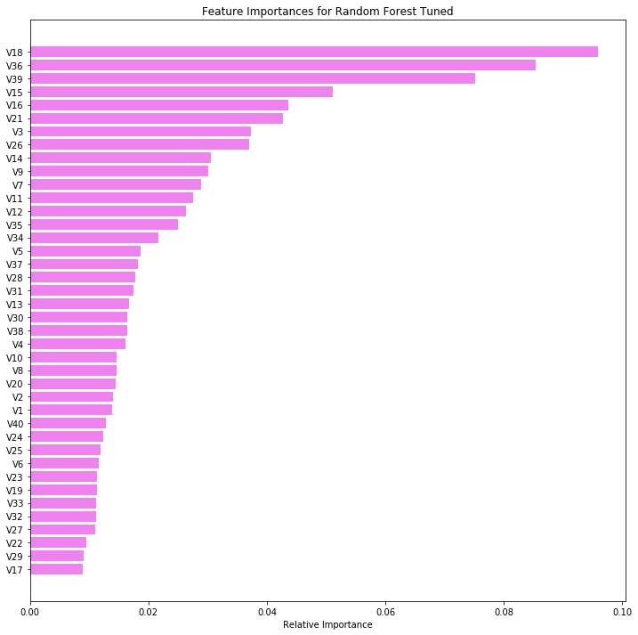

```python
feature_names = df.iloc[: , :-1].columns
importances = forest_grid_param.feature_importances_
indices = np.argsort(importances)

plt.figure(figsize=(12, 12))
plt.title("Feature Importances for Random Forest Tuned")
plt.barh(range(len(indices)), importances[indices], color="violet", align="center")
plt.yticks(range(len(indices)), [feature_names[i] for i in indices])
plt.xlabel("Relative Importance")
plt.show()
```

## Feature Importance For Random Forest

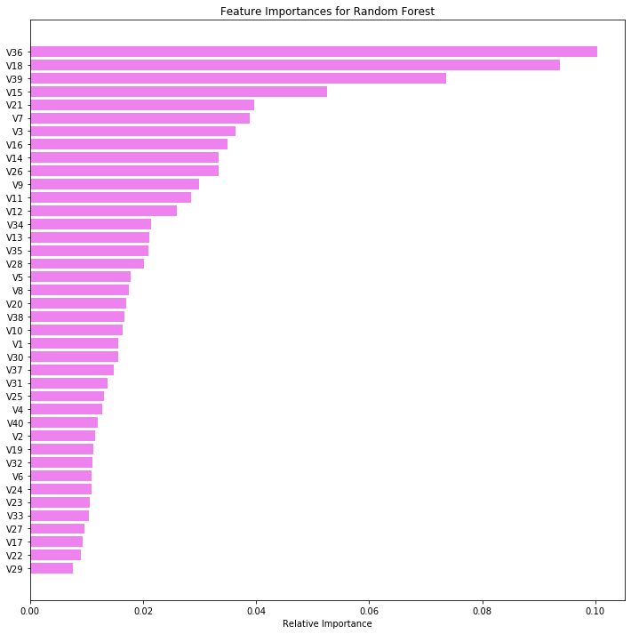

```python
feature_names = df.iloc[: , :-1].columns
importances = forest_SMOTE.feature_importances_
indices = np.argsort(importances)

plt.figure(figsize=(12, 12))
plt.title("Feature Importances for Random Forest")
plt.barh(range(len(indices)), importances[indices], color="violet", align="center")
plt.yticks(range(len(indices)), [feature_names[i] for i in indices])
plt.xlabel("Relative Importance")
plt.show()
```

## Top 5 features correlation with the target

```
(6.0, 0.0)
```

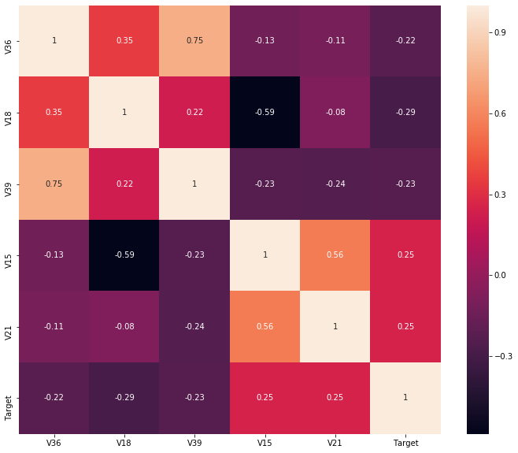

```python
df_corr = df[['V36','V18','V39','V15','V21','Target']]
corr1 = round(df_corr.corr(),2)
fig, ax = plt.subplots(figsize=(12, 10))
sns.heatmap(corr1,annot=True)
bottom, top = ax.get_ylim()
ax.set_ylim(bottom + 0.5, top - 0.5)
```

```python
df_corr.head(20)
```

|  | V36 | V18 | V39 | V15 | V21 | Target |
| --- | --- | --- | --- | --- | --- | --- |
| 0 | 6.667486 | 2.914097 | 2.950578 | -3.375815 | -2.388299 | 0 |
| 1 | 5.338051 | 1.508313 | 3.527309 | -3.547127 | -4.095749 | 0 |
| 2 | -3.197647 | 2.318208 | 0.562085 | -4.309957 | -11.599497 | 0 |
| 3 | -2.297780 | 0.907716 | -0.386345 | 0.193223 | -3.065122 | 0 |
| 4 | 5.360850 | 3.688534 | 3.839160 | -3.163804 | -2.143026 | 0 |
| 5 | 5.550100 | -1.281536 | 3.101430 | -0.453717 | -3.516555 | 0 |
| 6 | -3.229763 | 3.734452 | -3.644622 | -2.632684 | -0.886667 | 0 |
| 7 | 5.461345 | 2.348465 | 0.273964 | 0.764158 | 0.386345 | 0 |
| 8 | 1.366954 | -0.816698 | 1.090279 | -1.601142 | -0.984179 | 0 |
| 9 | 3.624347 | 0.677068 | 0.678703 | -0.923123 | -1.165392 | 0 |
| 10 | 10.387263 | -0.381192 | 3.349721 | -2.306126 | -5.074476 | 0 |
| 11 | -4.268517 | -1.908618 | -0.830889 | -3.472977 | -4.578679 | 1 |
| 12 | 2.964439 | 1.536752 | 1.354593 | -3.641924 | -3.011921 | 0 |
| 13 | 7.201055 | 0.635463 | 4.309201 | -2.730489 | -8.254886 | 0 |
| 14 | 0.931960 | -0.180159 | 1.719968 | -1.140086 | -4.192707 | 0 |
| 15 | 6.951197 | 1.123645 | 2.343985 | -0.236252 | -1.019950 | 0 |
| 16 | 1.371300 | 0.106859 | 0.831132 | -2.877902 | -5.409204 | 0 |
| 17 | 1.376268 | -2.360998 | 0.543871 | 0.734111 | -2.307024 | 0 |
| 18 | -0.270990 | 4.080217 | -0.065326 | -7.616213 | -4.583799 | 0 |
| 19 | 0.471354 | 2.919365 | 1.472707 | 0.923589 | -0.060924 | 0 |

### Observation :

The V36,V18,V39 are negatively corelated with the target value wheras th V15,V21 are posively corerelated with the taget value.

## Test set final performance

```python
df_test = pd.read_csv("Test.csv")
```

```python
X_test_data = df_test.iloc[: , :-1]
y_test_data=df_test[df_test.columns[-1]]
```

```python
X_test_data = imputer.transform(X_test_data)

print('Missing: %d' % sum(isnan(X_test_data).flatten()))
```

```
Missing: 0
```

```python
df_model_test= pd.DataFrame()
df_model_test = df_model_test.append(model_selection_dataframe
                                               ('8','Random Forest with Over Sampling',forest_SMOTE,X_test_data,y_test_data), ignore_index = True)

df_model_test = df_model_test.append(model_selection_dataframe
                                               ('16','Random Forest with Over Sampling Tuned Param',forest_grid_param,X_test_data,y_test_data), ignore_index = True)
```

```python
df_model_test
```

|  | SNO | Model Name | Accuracy | Recall | Precision | F1 | Minimum_Vs_Model_cost |
| --- | --- | --- | --- | --- | --- | --- | --- |
| 0 | 8 | Random Forest with Over Sampling | 0.9899 | 0.850091 | 0.960744 | 0.902037 | 0.792754 |
| 1 | 16 | Random Forest with Over Sampling Tuned Param | 0.9893 | 0.846435 | 0.952675 | 0.896418 | 0.787428 |

```python
def roc(name,model,y_pred,y_test,X_test):
    ns_probs = [0 for _ in range(len(y_test))]

    # predict probabilities
    lr_probs = model.predict_proba(X_test)
    # keep probabilities for the positive outcome only
    lr_probs = lr_probs[:, 1]
    # calculate scores
    ns_auc = roc_auc_score(y_test, ns_probs)
    lr_auc = roc_auc_score(y_test, lr_probs)
    # summarize scores
    print('No Skill: ROC AUC=%.3f' % (ns_auc))
    print(name  ,': ROC AUC=%.3f' % (lr_auc))
    # calculate roc curves
    ns_fpr, ns_tpr, _ = roc_curve(y_test, ns_probs)
    lr_fpr, lr_tpr, _ = roc_curve(y_test, lr_probs)
    # plot the roc curve for the model
    pyplot.plot(ns_fpr, ns_tpr, linestyle='--', label='No Skill')
    pyplot.plot(lr_fpr, lr_tpr, marker='.', label= name)
    # axis labels
    pyplot.xlabel('False Positive Rate')
    pyplot.ylabel('True Positive Rate')
    # show the legend
    pyplot.legend()
    # show the plot
    pyplot.show()
    return
```

## Pipelines to build the final model

```python
model = Pipeline(
    steps=[
        ("pre", KNNImputer()),
        (
            "Random_forest",
            RandomForestClassifier()
        ),
    ]
)
# Fit the model on training data
model.fit(X_train_over, y_train_over)
```

```
Pipeline(memory=None,
         steps=[('pre',
                 KNNImputer(add_indicator=False, copy=True,
                            metric='nan_euclidean', missing_values=nan,
                            n_neighbors=5, weights='uniform')),
                ('Random_forest',
                 RandomForestClassifier(bootstrap=True, ccp_alpha=0.0,
                                        class_weight=None, criterion='gini',
                                        max_depth=None, max_features='auto',
                                        max_leaf_nodes=None, max_samples=None,
                                        min_impurity_decrease=0.0,
                                        min_impurity_split=None,
                                        min_samples_leaf=1, min_samples_split=2,
                                        min_weight_fraction_leaf=0.0,
                                        n_estimators=100, n_jobs=None,
                                        oob_score=False, random_state=None,
                                        verbose=0, warm_start=False))],
         verbose=False)
```

```python
df_test = pd.read_csv("Test.csv")
X_test_data = df_test.iloc[: , :-1]
y_test_data=df_test[df_test.columns[-1]]
```

```
No Skill: ROC AUC=0.500
Random Forest Pipeline : ROC AUC=0.936
```

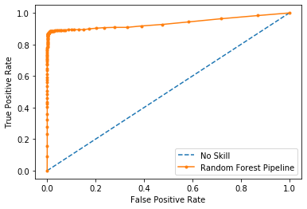

```python
roc("Random Forest Pipeline",model,y_test_pred,y_test_data,X_test_data)
```

# Business Insights and Conclusions

1) Based on the feature importance , V36,V18,V39 are among top 5 important features and the decrease in the values of the feature leads to the failure of the machines/components for the wind energy production

2) Based on the feature importance , V15,V21 are among top 5 important features and the increase in the values of the feature leads to the failure of the machines/components for the wind energy production